# Central Limit theorem Simulation for exponential distribution

Shashank Sane

March 3, 2017

## Synopsis

This article explores exponential distribution and compares the same with central limit theorem.We would be using the R function rexp(n, lambda) to generate random samples of the exponential distribution. We will do 1000 simulations of sample draws of 40 distributions each. We would explore how the mean and variance of the samples compare against the theoretical mean and variance.

load required libraries

```r
library(ggplot2)
library(knitr)
```

set lambda for exponential distribution

```r
lambda <- 0.2

# Theoretical mean for exponential distribution:
mean_theoretical <- 1/lambda

# Theoretical variance for exponential distribution:
var_theoretical <- (1/lambda)^2
```

Now we will do 1000 simulations of 40 samples generated from exponential distribution. We would use R function rexp() to simulate the draws

```r
# Number of simulations
nosim <- 1000

# Number of samples for each simulation
n <- 40

#set seed for random sampling
set.seed(0)

# Generate random samples and store in matrix sim.mat
sim.mat <- sim.mat <- matrix(rexp(n*nosim,rate=lambda),nosim)
```

Now we will find out the mean for each simulation and store them in list mean_dist

we will also find out the variance for each simulation and also store them in list var_dist

```r
# sample mean distribution list
mean_dist <- apply(sim.mat,1,mean)

# sample variance distribution list
var_dist <- apply(sim.mat,1,var)
```

find out sample mean(mean of the list of sample means) and the sample variance(mean of the list of sample variance) and compare them to the theoretical mean and theoretical variance.

```r
# sample mean
mean_sample <- mean(mean_dist)

# sample variance
var_sample <- mean(var_dist)
```

Comparison with theoretical mean and theoretical variance, **sample mean** = 4.9896776 and the **theoretical mean** = 5 while **sample variance** = 25.2377067 and the **theoretical variance** = 25

*As can be seen from above they are pretty close!!*

We will check the distribution of mean for the samples drawn. Note that the Central Limit Theorum states that for large sample size the averages are approximately normal and centered around population mean.

But first we will look at how a distribution of 1000 simulations from exponential distribution looks like:

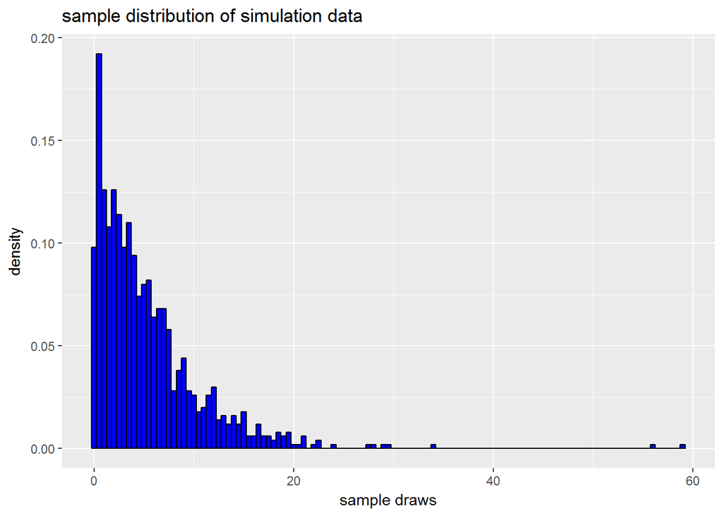

```r
# generate 1000 random sample draws of exponential distribution and store them in data frame dfSample
dfsample <- as.data.frame(rexp(1000,rate=lambda))
names(dfsample)<- c("RV")

# Draw histogram to view the sample draw distribution
ggplot(data=dfsample)+geom_histogram(mapping=aes(x=dfsample$RV,y=..density..),binwidth = 0.5,fill="blue",col="black")+xlab("sample draws")+ggtitle("sample distribution of simulation data")
```

Now draw the distribution of sample means for 1000 simulations. We would also overlay normal curve to visualize how the distribution approximates to normal distribution.

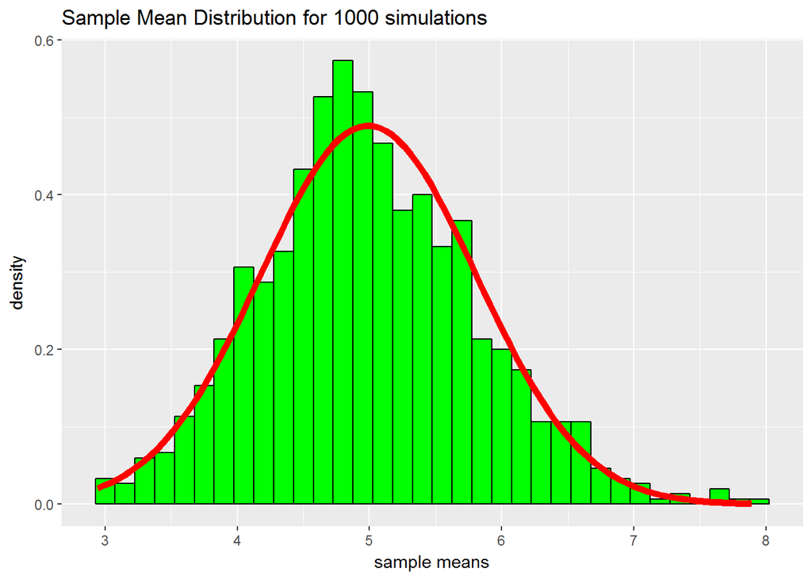

```r
# Convert mean_dist to dataframe so as to use in ggplot
mean_dist <- as.data.frame(mean_dist)

# draw the plot for sample mean distribution
a  <- ggplot(data=mean_dist)+geom_histogram(mapping=aes(x=mean_dist,y=..density..),binwidth = 0.15,fill="green",col="black")

# add density curve
a + stat_function(fun=dnorm,args=list(mean=mean(mean_dist$mean_dist),sd=sd(mean_dist$mean_dist)),col="red",lwd=2)+xlab("sample means")+ylab("density")+ggtitle("Sample Mean Distribution for 1000 simulations")
```

*As can be seen from above figure the sample mean distribution fits nicely for normal distribution centered around theroretical mean 5 as predicted by Central Limit Theorem!!!.*